# Assignment 3

## Dealing with Missing Values

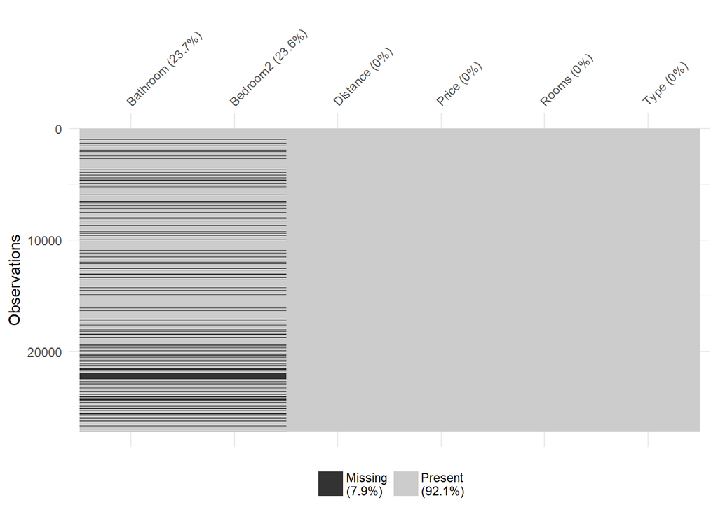

```r
#Removing missing prices
houses_PM <- houses %>%
    filter(!is.na(houses$Price))

vis_miss(houses_PM, sort_miss = TRUE)
```

```r
s_miss_PM <- miss_summary(houses_PM)
s_miss_PM$miss_case_table
```

```
## [[1]]
## # A tibble: 4 x 3
##   n_miss_in_case n_cases pct_miss
##            <int>   <int>    <dbl>
## 1              0   20800 76.3
## 2              1       6  0.0220
## 3              2    6440 23.6
## 4              3       1  0.00367
```

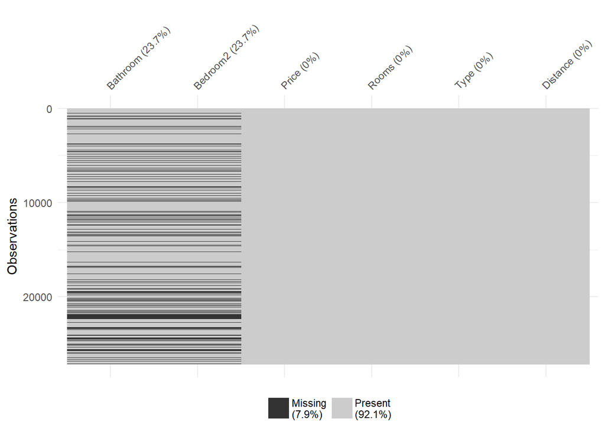

```r
houses_clean <- houses_PM %>%
  #Removing 0 bedroom/bathroom values
    filter(Bedroom2 > 0 | is.na(Bedroom2)) %>%
  filter(Bathroom > 0 | is.na(Bathroom)) %>%
  #Removing single observations that cannot be reasonably imputed- impact is minimal due to size of dataset
    filter(Rooms != 9) %>%
  filter(!(is.na(Distance)))

vis_miss(houses_clean, sort_miss = TRUE)
```

```r
s_miss_clean <- miss_summary(houses_clean)
s_miss_clean$miss_case_table
```

```
## [[1]]
## # A tibble: 3 x 3
##   n_miss_in_case n_cases pct_miss
##            <int>   <int>    <dbl>
## 1              0   20756  76.3
## 2              1       6   0.0221
## 3              2    6439  23.7
```

```r
#Proportion missing by room value
s_miss_group <- houses_clean %>%
  group_by(Rooms) %>%
    miss_summary()
s_miss_group$miss_case_table
```

```
## [[1]]
## # A tibble: 25 x 4
##    Rooms n_miss_in_case n_cases pct_miss
##    <int>          <int>   <int>    <dbl>
##  1     2              0    4587  67.8
##  2     2              2    2179  32.2
##  3     3              0    9376  78.5
##  4     3              1       2   0.0168
##  5     3              2    2562  21.5
##  6     4              0    4851  82.1
##  7     4              1       2   0.0338
##  8     4              2    1059  17.9
##  9     1              0     769  64.4
## 10     1              1       1   0.0837
## # ... with 15 more rows
```

```r
#Proportion missing by Type
s_miss_group2 <- houses_clean %>%
  group_by(Type) %>%
    miss_summary()
s_miss_group2$miss_case_table
```

```
## [[1]]
## # A tibble: 9 x 4
##   Type  n_miss_in_case n_cases pct_miss
##   <chr>          <int>   <int>    <dbl>
## 1 h                  0   15706  85.1
## 2 h                  1       3   0.0163
## 3 h                  2    2739  14.8
## 4 t                  0    1575  55.0
## 5 t                  1       2   0.0699
## 6 t                  2    1285  44.9
## 7 u                  0    3475  59.0
## 8 u                  1       1   0.0170
## 9 u                  2    2415  41.0
```

- As predicting price is the purpose of our model, imputing price just to predict it would be pointless and would artificially improve the quality of any model we produce. Thus, observations that contained a missing Price value were removed. This also included observations that also missed a combination of Bedroom2 and Bathroom as well, but since Price was missing in these observations anyway there is no point in imputing them.
- Observations that had 0 values in either Bedroom2 or Bathroom were removed, as it seemed infeasible that a residence would not have either a bedroom or bathroom, or both.
- Single observations were also removed, namely an observation where both Bedroom2 and Bathroom was missing and was unsuitable for our imputing method, and an observation that missed Bedroom2, Bathroom and Distance. It was removed since we did not want to impute Distance depending on the remaining variables, since we did not consider them directly related to Distance.
- Comparing the missing case tables of Rooms and Type, a better spread of missing value cases is seen across Rooms rather than Type, which is expected due to the lower number of factors for Type.

### Imputing Values

```r
imputed_means <- as.table(unlist(by(houses_clean[5:6], houses_clean[2], function(df) colMeans(df, na.rm = TRUE))))
imputed_means <- as.data.frame(imputed_means) %>%
  separate(col = Var1, into = c("Rooms", "Room Type"), sep = "[.]") %>%
  spread(key = "Room Type", value = Freq)

houses_comp <- houses_clean %>%
  #Finds the corresponding Rooms mean of any missing value to impute missing Bedroom2 and Bathroom variables
    #not using k nearest neighbours as values are discrete
  #adding imputed dummy variables for plotting- indicates if the variable was imputed
    mutate(imputed_ba = ifelse(is.na(Bathroom),
                                                         "Yes",
                                                         "No"),
                 imputed_be = ifelse(is.na(Bedroom2),
                                                        "Yes",
                                                        "No"),
             Bathroom = ifelse(is.na(Bathroom),
                                                 imputed_means[match(Rooms,imputed_means[,1]),2],
                                                 Bathroom),
         Bedroom2 = ifelse(is.na(Bedroom2),
                                            imputed_means[match(Rooms,imputed_means[,1]),3],
                                            Bedroom2))
```

- Imputation using impute.knn could not be used between Rooms and Bathroom nor between Rooms and Bedroom2 as all of the variables in question were discrete.
  - Price could not be used in place of Rooms since the values of Bathroom and Bedroom would be used to predict Price later, which would affect the model we create.
  - Any relationship between Distance and either Bathroom or Bedroom2 is highly unlikely to display the entire picture, as any perceived effect may be attributed to the land size, which is not being investigated.
  - Finally, Residence Type was not chosen due to the small number of factors, which would give a more general imputed value whereas imputing by Rooms would give greater flexibility in imputed values.

# Part 2: Plots

```r
#Recoding Type to meaning for clarity
houses_comp <- houses_comp %>% mutate(Type=recode(Type,"h"="House","t"="Townhouse","u"="Unit"))

#Creating plot-friendly data- rounding imputed values
houses_plot <- houses_comp %>%
    mutate_if(is.double, funs(round(.,0)))
```

## Price Distribution

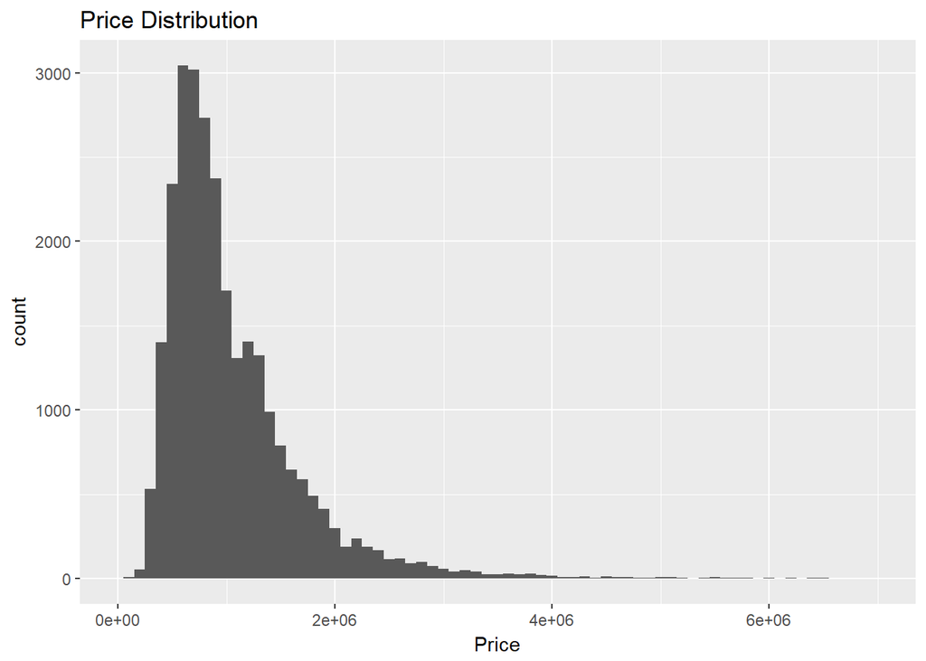

```r
houses_comp %>%
    ggplot(aes(x = Price)) +
    geom_histogram(binwidth=100000) +
    coord_cartesian(xlim = c(0, 7000000)) +
    ggtitle("Price Distribution")
```

- The plot demonstrates that Price is right-skewed

## Violin Plots

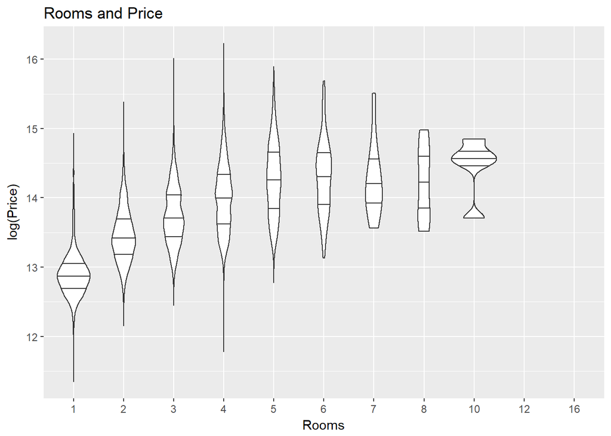

```r
houses_plot %>%
    ggplot(aes(x=as.factor(Rooms), y = log(Price))) +
    geom_violin(draw_quantiles = c(0.25,0.5,0.75)) +
    xlab("Rooms") +
    ggtitle("Rooms and Price")
```

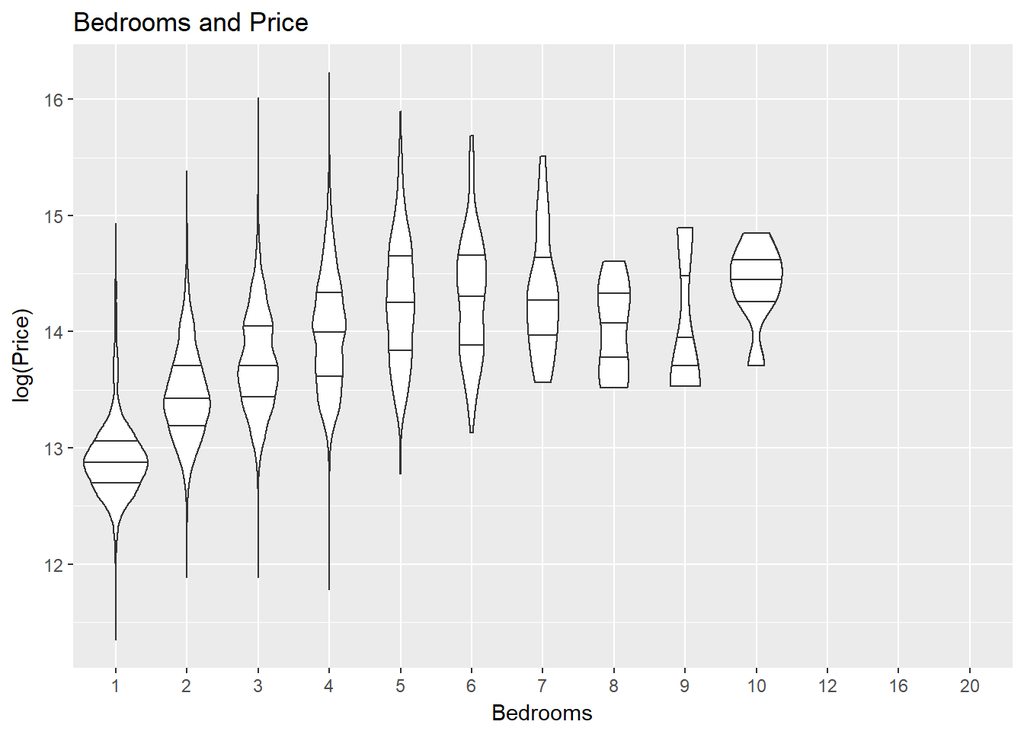

```r
houses_plot %>%
    ggplot(aes(x=as.factor(Bedroom2), y = log(Price))) +
    geom_violin(draw_quantiles = c(0.25,0.5,0.75)) +
    xlab("Bedrooms") +
    ggtitle("Bedrooms and Price")
```

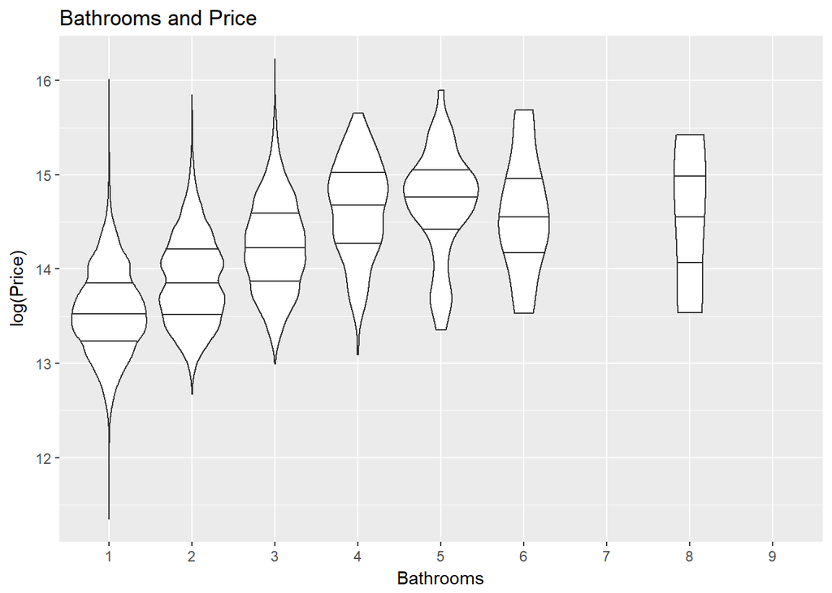

```r
houses_plot %>%
    ggplot(aes(x=as.factor(Bathroom), y = log(Price))) +
    geom_violin(draw_quantiles = c(0.25,0.5,0.75)) +
    xlab("Bathrooms") +
    ggtitle("Bathrooms and Price")
```

- The Violin Plots demonstrate positive relationships between Price and Rooms, between Price and Bedrooms and between Price and Bathrooms.

## Violin Plots Facetted by Residence Type

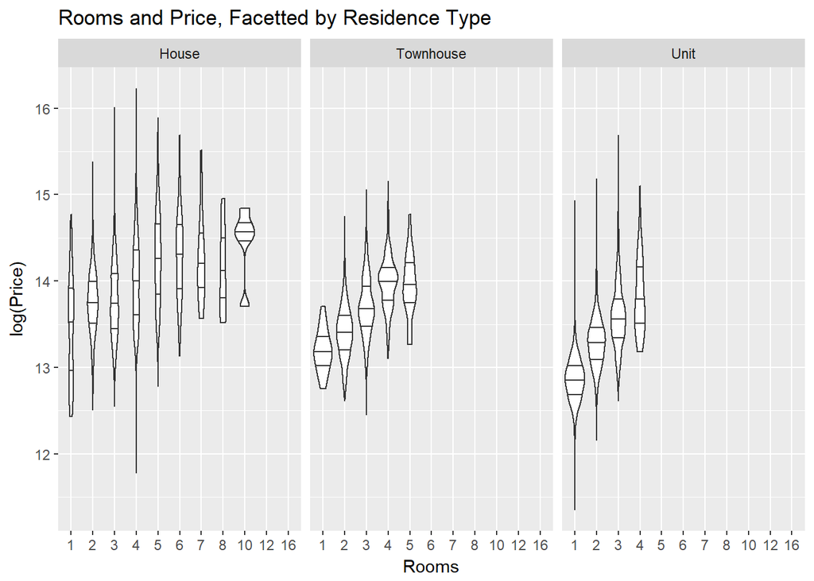

```r
houses_plot %>%
    ggplot(aes(x=as.factor(Rooms), y = log(Price))) +
    geom_violin(draw_quantiles = c(0.25,0.5,0.75)) +
    xlab("Rooms") + facet_grid(~Type) +
    ggtitle("Rooms and Price, Facetted by Residence Type")
```

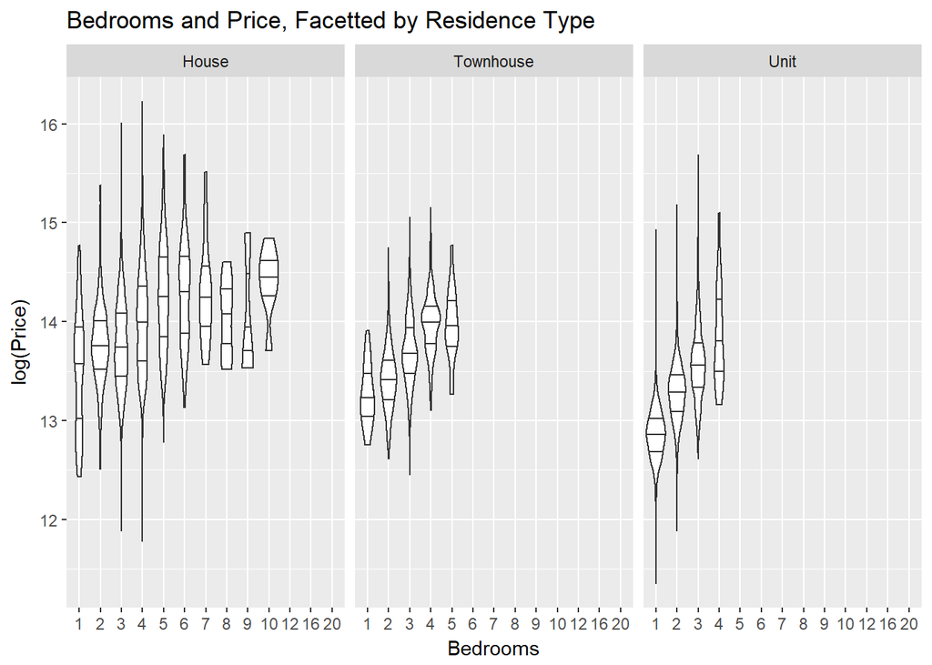

```r
houses_plot %>%
    ggplot(aes(x=as.factor(Bedroom2), y = log(Price))) +
    geom_violin(draw_quantiles = c(0.25,0.5,0.75)) +
    xlab("Bedrooms") + facet_grid(~Type) +
    ggtitle("Bedrooms and Price, Facetted by Residence Type")
```

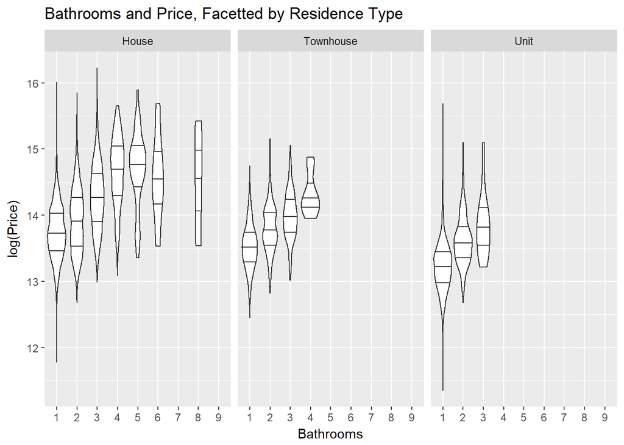

```r
houses_plot %>%
    ggplot(aes(x=as.factor(Bathroom), y = log(Price))) +
    geom_violin(draw_quantiles = c(0.25,0.5,0.75)) +
    xlab("Bathrooms") + facet_grid(~Type) +
    ggtitle("Bathrooms and Price, Facetted by Residence Type")
```

- When the Violin Plots are facetted by Residence Type it is clear that there is another relationship between Bedrooms and Residence Type as well as Bathrooms and Residence Type. In both cases, there are varying slopes for each Residence Type. This suggests the possibility of interactions between these variables. There may also be a relationship between Rooms and Type.

## Scatterplots

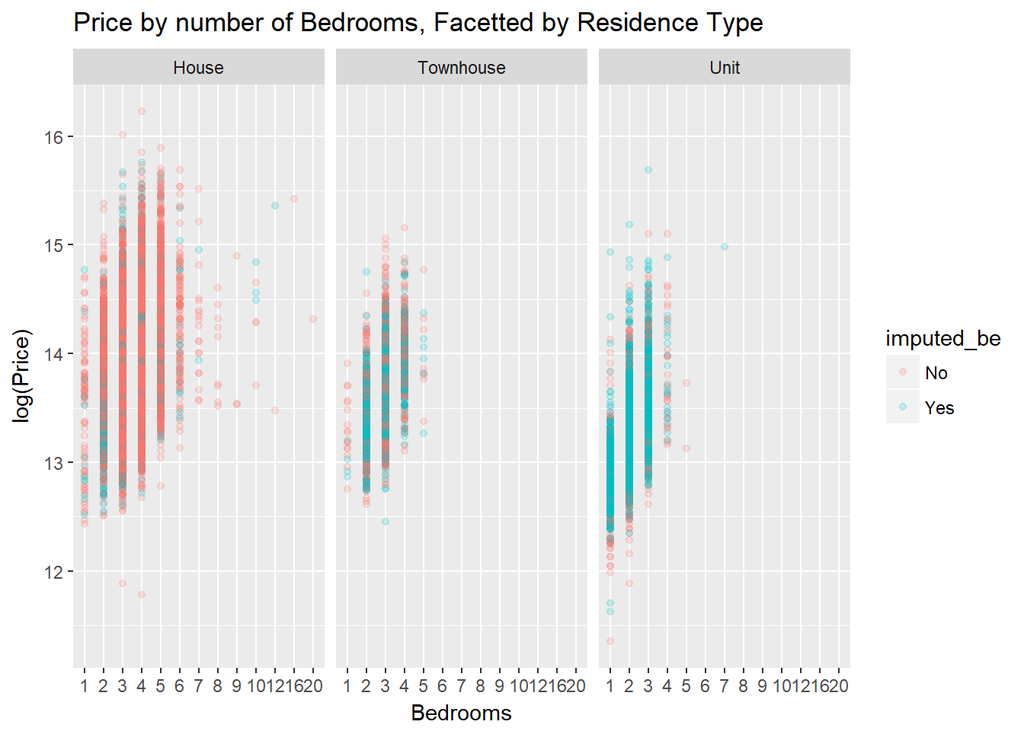

```r
houses_plot %>%
    ggplot(aes(x = as.factor(Bedroom2), y = log(Price), colour = imputed_be)) +
    geom_point(alpha = 0.2) +
    xlab("Bedrooms") +
    ggtitle("Price by number of Bedrooms, Facetted by Residence Type") + facet_grid(~Type)
```

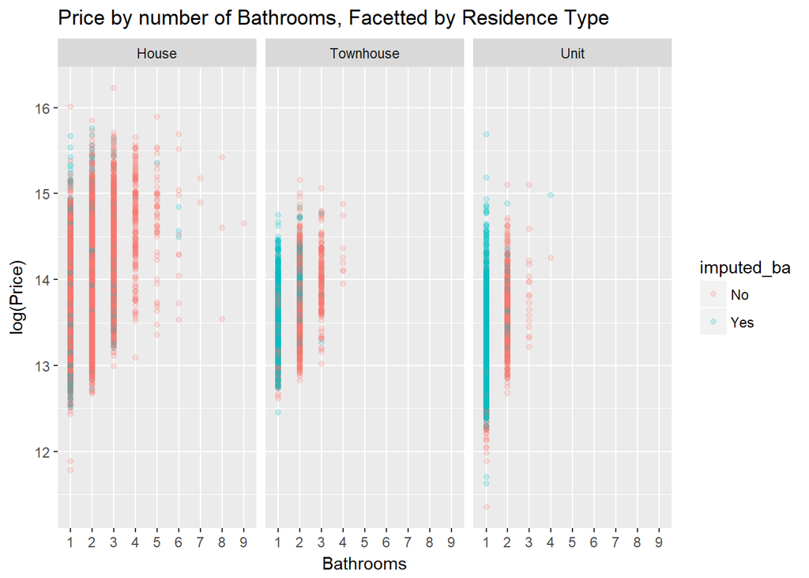

```r
houses_plot %>%
    ggplot(aes(x = as.factor(Bathroom), y = log(Price), colour = imputed_ba)) +
    geom_point(alpha = 0.2) +
    xlab("Bathrooms") +
    ggtitle("Price by number of Bathrooms, Facetted by Residence Type") + facet_grid(~Type)
```

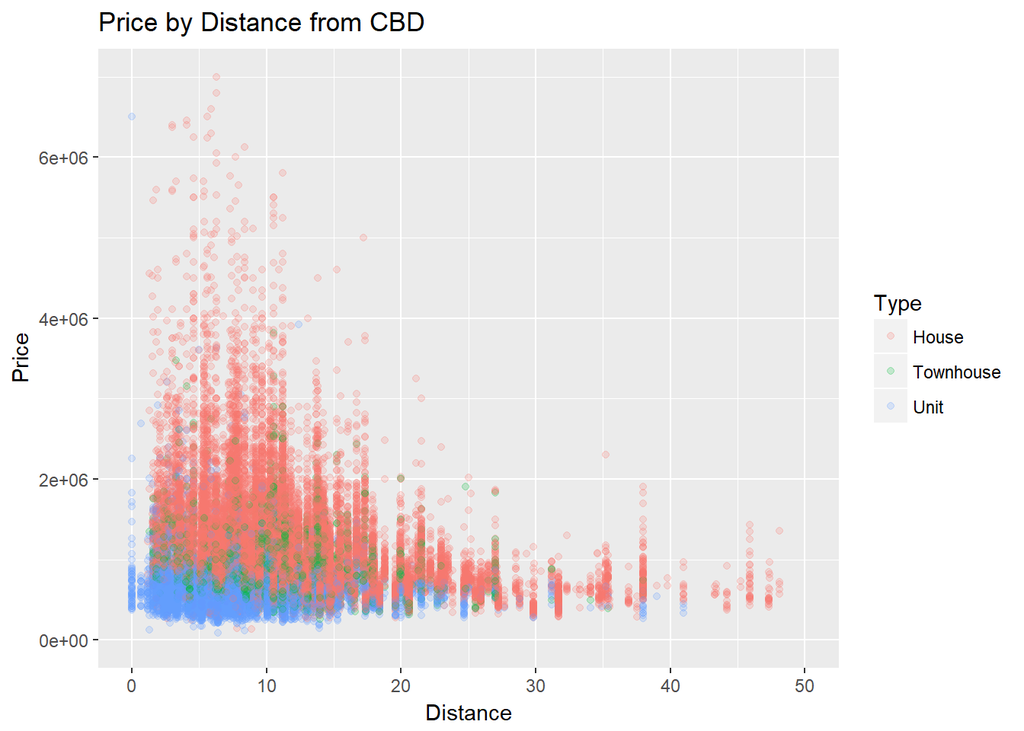

```r
houses_comp %>%
    ggplot(aes(x = Distance, y = Price, colour = Type)) +
    geom_point(alpha = 0.2) +
    coord_cartesian(xlim = c(0,50), ylim = c(0, 7000000)) +
    ggtitle("Price by Distance from CBD")
```

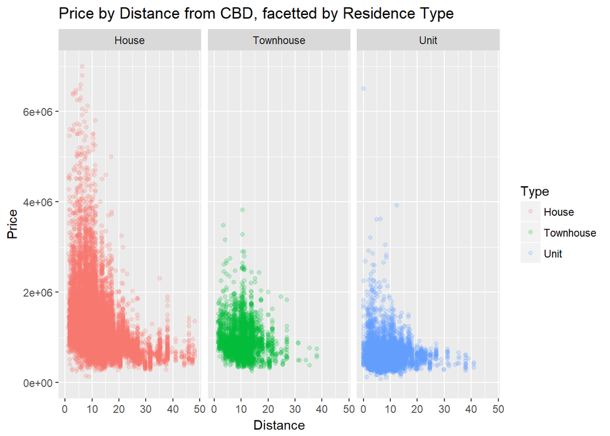

```r
houses_comp %>%
    ggplot(aes(x = Distance, y = Price, colour = Type)) +
    geom_point(alpha = 0.2) +
    facet_grid(~Type) + coord_cartesian(ylim = c(0, 7000000)) +
    ggtitle("Price by Distance from CBD, facetted by Residence Type")
```

- When observing the Scatterplot of Price by Bedrooms again facetted by Residence Type, and taking into account where values were imputed - it was seen that a large proportion of values for townhouses and units were imputed, and therefore were initally missing.
- Distance is heavily right-skewed, where properties closer to the CBD are generally more expensive. When facetted by Residence Type this trend is particularly obvious with houses. The difference in slopes between Residence Types suggests a possible interaction between Distance and Type.

# Part 3: Modelling

## Independent Variable Models

```r
#Transforming data
houses_comp<-houses_comp %>%
  mutate(log_price = log10(Price)) %>%
  mutate(log_dist = log1p(Distance)) %>%
  mutate(type_c = factor(Type, ordered=FALSE))

#Models generated by considering the addition of one extra variable each time
#Single Explanatory Variable
mod1_ind1<-lm(log_price~Rooms,data=houses_comp)
mod1_ind2<-lm(log_price~Rooms+type_c,data=houses_comp)
mod1_ind3<-lm(log_price~Rooms+type_c+log_dist,data=houses_comp)
mod1_ind4<-lm(log_price~Rooms+type_c+log_dist+Bedroom2,data=houses_comp)
mod1_ind5<-lm(log_price~Rooms+type_c+log_dist+Bedroom2+Bathroom,data=houses_comp)

glance(mod1_ind1)
```

```
##   r.squared adj.r.squared     sigma statistic p.value df   logLik
## 1  0.278698     0.2786715 0.1907252   10509.2       0  2 6474.377
##         AIC       BIC deviance df.residual
## 1 -12942.75 -12918.12 989.3937       27199
```

```r
glance(mod1_ind2)
```

```
##   r.squared adj.r.squared     sigma statistic p.value df   logLik
## 1 0.3268623     0.3267881 0.1842542  4402.108       0  4 7414.281
##         AIC       BIC deviance df.residual
## 1 -14818.56 -14777.51 923.3277       27197
```

```r
glance(mod1_ind3)
```

```
##   r.squared adj.r.squared     sigma statistic p.value df   logLik
## 1 0.4810468     0.4809705 0.1617847  6302.374       0  5 10952.26
##         AIC       BIC deviance df.residual
## 1 -21892.53 -21843.26 711.8363       27196
```

```r
glance(mod1_ind4)
```

```
##   r.squared adj.r.squared     sigma statistic p.value df  logLik      AIC
## 1 0.4817002     0.4816049 0.1616858  5054.927       0  6 10969.4 -21924.8
##         BIC deviance df.residual
## 1 -21867.32 710.9401       27195
```

```r
glance(mod1_ind5)
```

```
##   r.squared adj.r.squared    sigma statistic p.value df   logLik       AIC
## 1 0.4980255     0.4979147 0.159122  4496.677       0  7 11404.67 -22793.35
##         BIC deviance df.residual
## 1 -22727.66 688.5471       27194
```

```r
tidy(mod1_ind5)
```

```
##              term    estimate   std.error   statistic       p.value
## 1     (Intercept)  6.04917584 0.005563904 1087.217903  0.000000e+00
## 2           Rooms  0.07296235 0.004334600   16.832546  2.947781e-63
## 3 type_cTownhouse -0.06972138 0.003274712  -21.290842 9.014418e-100
## 4      type_cUnit -0.18845526 0.002904031  -64.894363  0.000000e+00
## 5        log_dist -0.16541745 0.001844120  -89.699928  0.000000e+00
## 6        Bedroom2  0.01237935 0.004293151    2.883511  3.935777e-03
## 7        Bathroom  0.06009690 0.002020816   29.738932 2.792050e-191
```

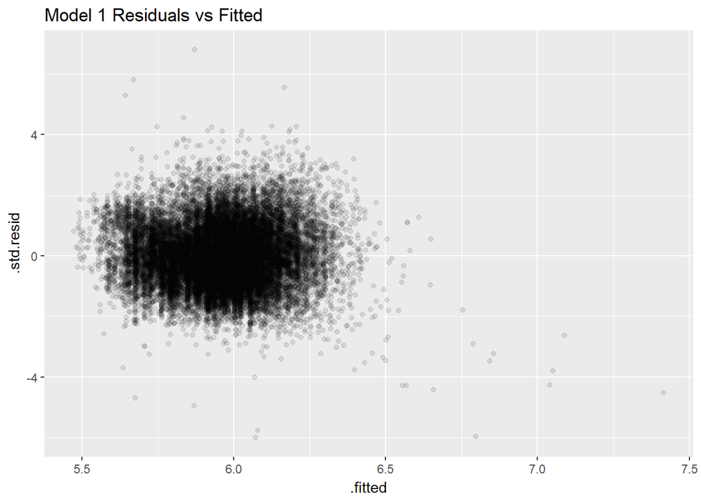

```r
mod1_a<-augment(mod1_ind5,houses_comp)

ggplot(mod1_a, aes(x=.fitted, y=.std.resid)) +
  geom_point(alpha=0.1) + ggtitle("Model 1 Residuals vs Fitted")
```

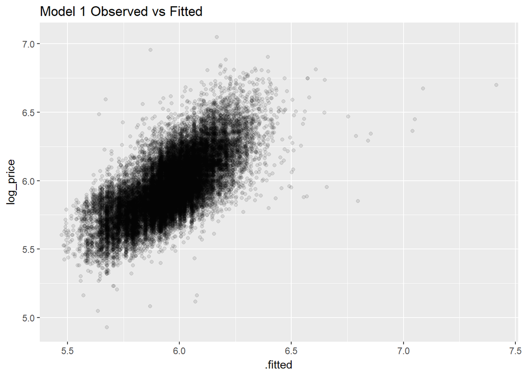

```r
ggplot(mod1_a, aes(x=.fitted, y=log_price)) +
  geom_point(alpha=0.1) + ggtitle("Model 1 Observed vs Fitted")
```

- The best model found was when all variables were added, as it had the highest Adjusted R^2 of all the models we tested (a subset is shown above). The AIC, BIC and deviance were also smallest when dealing with the last model which included all variables. This was expected as our plotting suggested that all of the variables had some sort of effect on Price.
- Looking at the coefficients, we can see that compared to the base case (a residence which is either a house, cottage, villa, semi, or terrace) the number of Rooms, Bedrooms and Bathrooms will all positively impact Price. Conversely, if the residence were a unit/duplex or townhouse, or was further from the CBD, this would negatively impact Price.
- The current residual vs fitted plot suggests there is a non-linear structure possibly not captured

## Interaction Models

```r
#Testing interactions with Rooms, Bedroom and Bathroom with Residence Type
mod2_int1<-lm(log_price~Rooms+type_c+log_dist+Bedroom2+Bathroom+type_c*Rooms,data=houses_comp)
mod2_int2<-lm(log_price~Rooms+type_c+log_dist+Bedroom2+Bathroom+type_c*Bedroom2,data=houses_comp)
mod2_int3<-lm(log_price~Rooms+type_c+log_dist+Bedroom2+Bathroom+type_c*Bathroom,data=houses_comp)
mod2_int4<-lm(log_price~Rooms+type_c+log_dist+Bedroom2+Bathroom+type_c*Bedroom2+type_c*Bathroom,data=houses_comp)


#Testing interactions with Distance, Bedroom and Bathroom with Residence Type
mod2_int5 <- lm(log_price~Rooms+type_c+log_dist+Bedroom2+Bathroom+type_c*log_dist,data=houses_comp)
mod2_int6 <- lm(log_price~Rooms+type_c+log_dist+Bedroom2+Bathroom+type_c*log_dist+type_c*Bedroom2,data=houses_comp)
mod2_int7 <- lm(log_price~Rooms+type_c+log_dist+Bedroom2+Bathroom+type_c*log_dist+type_c*Bathroom,data=houses_comp)

glance(mod2_int1)
```

```
##   r.squared adj.r.squared     sigma statistic p.value df   logLik
## 1 0.5176013     0.5174594 0.1559942  3647.039       0  9 11945.68
##         AIC       BIC deviance df.residual
## 1 -23871.36 -23789.25 661.6953       27192
```

```r
glance(mod2_int2)
```

```
##   r.squared adj.r.squared     sigma statistic p.value df  logLik       AIC
## 1 0.5178394     0.5176975 0.1559557  3650.518       0  9 11952.4 -23884.79
##         BIC deviance df.residual
## 1 -23802.68 661.3688       27192
```

```r
glance(mod2_int3)
```

```
##   r.squared adj.r.squared     sigma statistic p.value df   logLik
## 1 0.5022851     0.5021387 0.1584513  3430.211       0  9 11520.58
##         AIC       BIC deviance df.residual
## 1 -23021.16 -22939.05 682.7042       27192
```

```r
glance(mod2_int4)
```

```
##   r.squared adj.r.squared     sigma statistic p.value df   logLik      AIC
## 1 0.5180504     0.5178731 0.1559273  2922.668       0 11 11958.35 -23892.7
##         BIC deviance df.residual
## 1 -23794.16 661.0794       27190
```

```r
glance(mod2_int5)
```

```
##   r.squared adj.r.squared     sigma statistic p.value df   logLik
## 1 0.5360263     0.5358898 0.1529861  3926.846       0  9 12475.33
##         AIC       BIC deviance df.residual
## 1 -24930.65 -24848.54 636.4223       27192
```

```r
glance(mod2_int6)
```

```
##   r.squared adj.r.squared     sigma statistic p.value df   logLik
## 1 0.5456553     0.5454882 0.1513959  3265.443       0 11 12760.55
##         AIC       BIC deviance df.residual
## 1 -25497.11 -25398.58 623.2143       27190
```

```r
glance(mod2_int7)
```

```
##   r.squared adj.r.squared     sigma statistic p.value df   logLik
## 1 0.5393719     0.5392025 0.1524392   3183.81       0 11 12573.75
##         AIC       BIC deviance df.residual
## 1 -25123.51 -25024.97 631.8331       27190
```

```r
tidy(mod2_int6)
```

```
##                        term     estimate   std.error   statistic
## 1               (Intercept)  6.221517288 0.006242910  996.573229
## 2                     Rooms  0.062539777 0.004137481   15.115423
## 3           type_cTownhouse -0.475651266 0.018476077  -25.744170
## 4                type_cUnit -0.720875314 0.010693933  -67.409745
## 5                  log_dist -0.218275704 0.002148352 -101.601441
## 6                  Bedroom2  0.004761429 0.004105422    1.159791
## 7                  Bathroom  0.070478071 0.001941110   36.308126
## 8  type_cTownhouse:log_dist  0.126432573 0.006741424   18.754578
## 9       type_cUnit:log_dist  0.158199568 0.004069711   38.872437
## 10 type_cTownhouse:Bedroom2  0.032851703 0.004519535    7.268824
## 11      type_cUnit:Bedroom2  0.082306619 0.003493060   23.562897
##          p.value
## 1   0.000000e+00
## 2   2.073976e-51
## 3  2.017643e-144
## 4   0.000000e+00
## 5   0.000000e+00
## 6   2.461443e-01
## 7  6.517723e-282
## 8   5.521821e-78
## 9  9.881313e-322
## 10  3.724046e-13
## 11 1.532461e-121
```

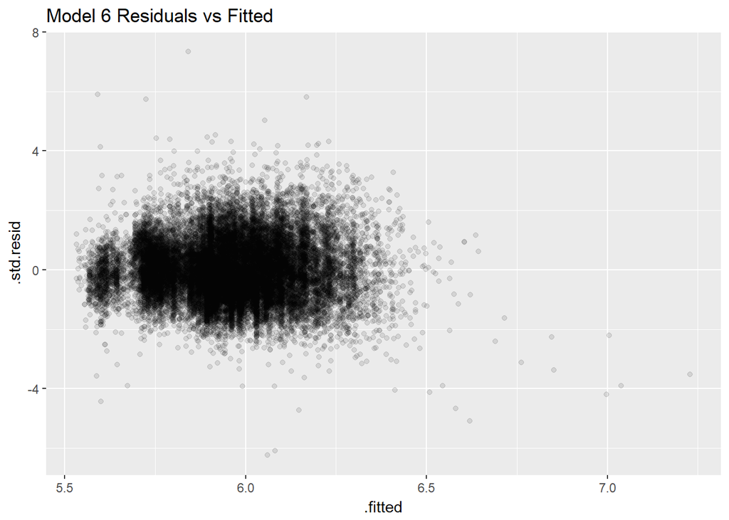

```r
mod2_a<-augment(mod2_int6,houses_comp)

ggplot(mod2_a, aes(x=.fitted, y=.std.resid)) +
  geom_point(alpha=0.1) + ggtitle("Model 6 Residuals vs Fitted")
```

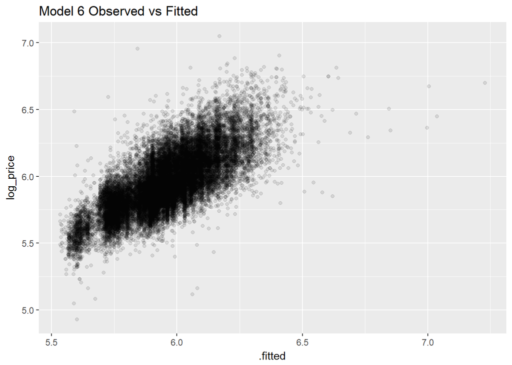

```r
ggplot(mod2_a, aes(x=.fitted, y=log_price)) +
  geom_point(alpha=0.1) + ggtitle("Model 6 Observed vs Fitted")
```

- The interaction between Type and Bedroom2 exhibits a slope which was captured in previous plots and its inclusion resulted in the increase of the adjusted R^2 value
- The interaction between Type and Distance also exhibited a slope, and its inclusion also contributed to the increased adjusted R^2 value.
- The interactions between Type and Rooms is similar to the interaction between Type and Bedroom2, which may in part be due to imputation of values from Rooms. Due to this, including both interactions in the model provides little improvement to the fit so only Bedroom2’s interaction was ultimately included.

## Inference

```r
houses_coefs<-bind_cols(tidy(mod2_int6), confint_tidy(mod2_int6))

confint_tidy(mod2_int6)
```

```
##        conf.low   conf.high
## 1   6.209280863  6.23375371
## 2   0.054430102  0.07064945
## 3  -0.511865324 -0.43943721
## 4  -0.741835971 -0.69991466
## 5  -0.222486585 -0.21406482
## 6  -0.003285408  0.01280827
## 7   0.066673396  0.07428275
## 8   0.113219035  0.13964611
## 9   0.150222727  0.16617641
## 10  0.023993183  0.04171022
## 11  0.075460042  0.08915320
```

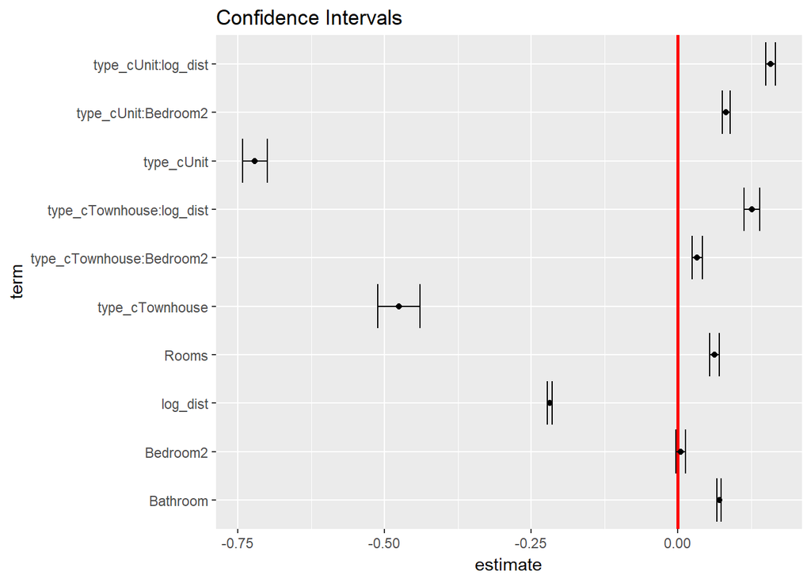

```r
ggplot(filter(houses_coefs, term != "(Intercept)"), aes(x=term, y=estimate)) +
  geom_hline(yintercept=0, colour="red", size=1) +
  geom_point() +
  geom_errorbar(aes(ymin=conf.low, ymax=conf.high)) +coord_flip() +ggtitle("Confidence Intervals")
```

- The parametric approach suggests that Bedroom2 is not important for predicting Price as its confidence interval crosses zero. This variable had the least effect on the model fit previously, however, it was included as there was still some change seen in the R^2 value.

# Summary

The model chosen captures the main effects of the explanatory variables as well as some interactions between Residence type, Bedroom2 and Distance. It was chosen out of several iterations of different models tested after observing the plots generated. While the residuals suggest that there may still be non-linear trends we have not captured, we chose to leave them out as our current model is already quite complex and adding higher order terms will further adversely impact ease of interpretation, especially given the interaction terms.